# Psych 251 PS4: Simulation + Analysis

Shawn T. Schwartz

November 21, 2021

This is problem set #4, in which we want you to integrate your knowledge of data wrangling with some basic simulation skills. It’s a short problem set to help consolidate your `ggplot2` skills and then help you get your feet wet in testing statistical concepts through “making up data” rather than consulting a textbook or doing math.

For ease of reading, please separate your answers from our text by marking our text with the `>` character (indicating quotes).

# Part 1: ggplot practice

> This part is a warmup, it should be relatively straightforward `ggplot2` practice.

```r
library(tidyverse)
```

> Load data from Frank, Vul, Saxe (2011, Infancy), a study in which we measured infants’ looking to hands in moving scenes. There were infants from 3 months all the way to about two years, and there were two movie conditions (`Faces_Medium`, in which kids played on a white background, and `Faces_Plus`, in which the backgrounds were more complex and the people in the videos were both kids and adults). An eye-tracker measured children’s attention to faces. This version of the dataset only gives two conditions and only shows the amount of looking at hands (other variables were measured as well).

```r
fvs <- read_csv("data/FVS2011-hands.csv")
```

> First, use `ggplot` to plot a histogram of the ages of children in the study. NOTE: this is a repeated measures design, so you can’t just take a histogram of every measurement.

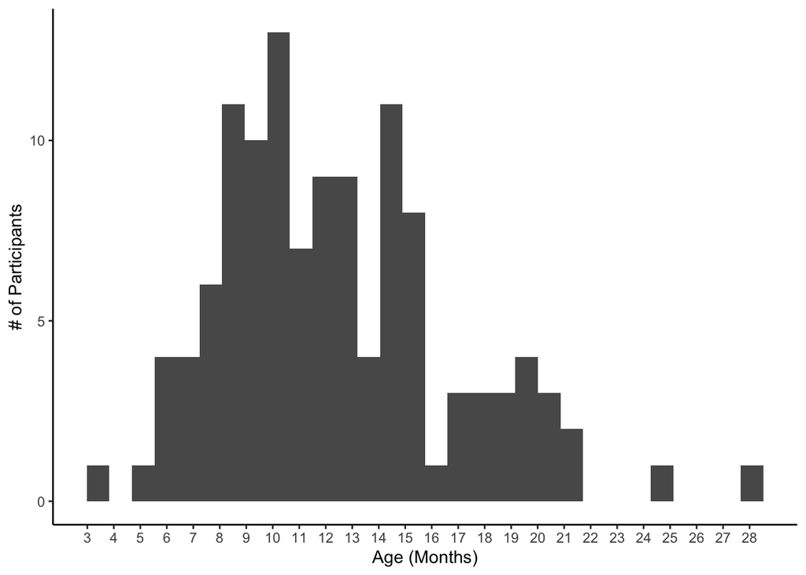

```r
## change global condition names to remove underscore and lower case text
fvs <- fvs |>
  mutate(condition = str_replace(condition, "\\_", " ")) |>
  mutate(condition = tolower(condition))

## remove repeated measures to get info about each participant once
fvs_indv <- fvs |>
  select(subid, age) |>
  group_by(subid) |>
  unique()

## individually:
##  take unique data set and plot each participant individually (and only once)
ggplot(fvs_indv, aes(age)) +
  geom_histogram(position = "dodge") +
  xlab("Age (Months)") +
  ylab("# of Participants") +
  xlim(c(floor(min(fvs_indv$age)), ceiling(max(fvs_indv$age)))) +
  scale_x_continuous(breaks = floor(min(fvs_indv$age)):ceiling(max(fvs_indv$age))) +
  scale_color_grey() +
  scale_fill_grey() +
  theme_classic()
```

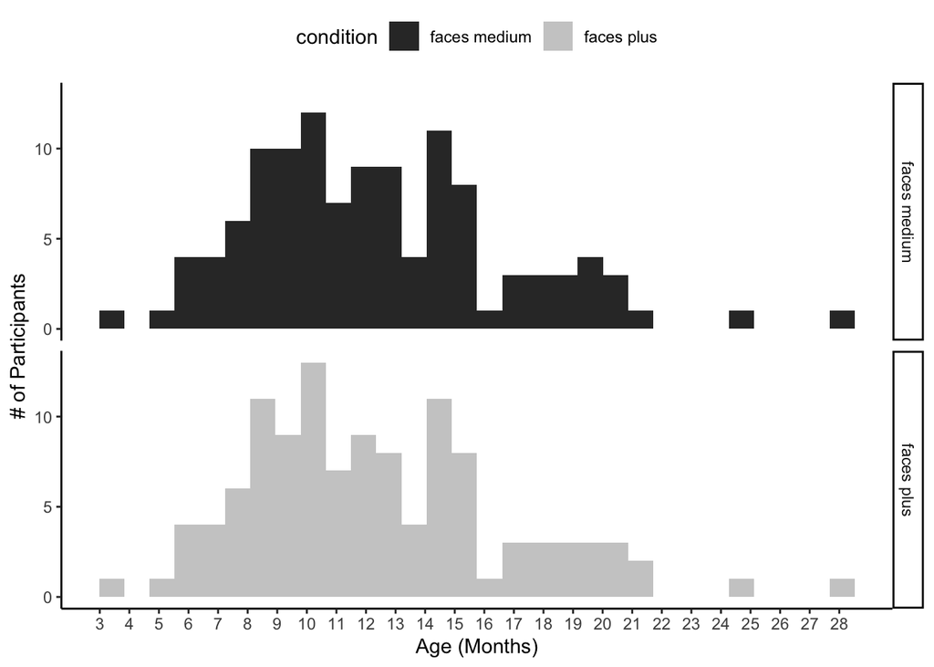

```r
## to validate: plot all together:
##  facet plot by condition to separate out repeated measures
##  ...slight deviations in frequencies between conditions indicative of missing/excluded data
ggplot(fvs, aes(age, fill = condition)) +
  facet_grid(condition ~ .) +
  geom_histogram(position = "dodge") +
  xlab("Age (Months)") +
  ylab("# of Participants") +
  xlim(c(floor(min(fvs$age)), ceiling(max(fvs$age)))) +
  scale_x_continuous(breaks = floor(min(fvs$age)):ceiling(max(fvs$age))) +
  scale_color_grey() +
  scale_fill_grey() +
  theme_classic() +
  theme(legend.position = "top")
```

> Second, make a scatter plot showing hand looking as a function of age and condition. Add appropriate smoothing lines. Take the time to fix the axis labels and make the plot look nice.

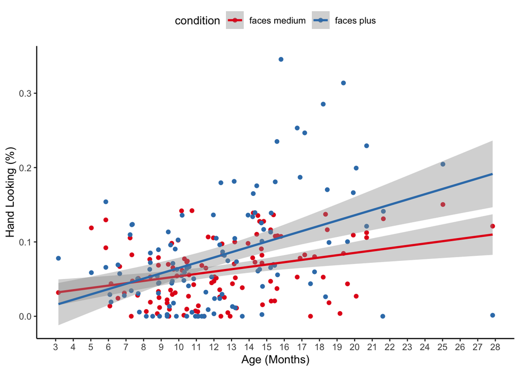

```r
ggplot(fvs, aes(x = age, y = hand.look, col = condition)) +
  geom_point() +
  geom_smooth(method = "lm") +
  xlim(c(floor(min(fvs$age)), ceiling(max(fvs$age)))) +
  scale_x_continuous(breaks = floor(min(fvs$age)):ceiling(max(fvs$age))) +
  xlab("Age (Months)") +
  ylab("Hand Looking (%)") +
  theme_classic() +
  scale_color_brewer(palette = "Set1") +
  theme(legend.position = "top")
```

> What do you conclude from this pattern of data?

There appears to be positively trending relationships of age (in months) in predicting the proportion of hand looking that occurred. Furthermore, visual inspection of these regression lines signal that there might be an interaction of hand looking proportion between the two conditions (i.e., faces medium, faces plus).

> What statistical analyses would you perform here to quantify these differences?

To quantify these differences, I would run a linear regression model with predictors of age, condition, and the interaction between the two. Below is the command I would run:

```r
model <- lm(hand.look ~ age + condition + age*condition,
            data = fvs)
summary(model)
```

```
##
## Call:
## lm(formula = hand.look ~ age + condition + age * condition, data = fvs)
##
## Residuals:
##       Min        1Q    Median        3Q       Max
## -0.190121 -0.036508 -0.001239  0.032091  0.239474
##
## Coefficients:
##                          Estimate Std. Error t value Pr(>|t|)
## (Intercept)              0.022394   0.015417   1.453  0.14772
## age                      0.003143   0.001176   2.673  0.00807 **
## conditionfaces plus     -0.028440   0.021680  -1.312  0.19089
## age:conditionfaces plus  0.003950   0.001653   2.389  0.01770 *
## ---
## Signif. codes:  0 '***' 0.001 '**' 0.01 '*' 0.05 '.' 0.1 ' ' 1
##
## Residual standard error: 0.05456 on 228 degrees of freedom
## Multiple R-squared:  0.1871, Adjusted R-squared:  0.1764
## F-statistic: 17.49 on 3 and 228 DF,  p-value: 2.955e-10
```

It therefore appears that age is a significant predictor of hand looking, regardless of condition (*p* = .008), and that there is a significant interaction between age and condition (*p* = .02). These quantitative results verify my intuition from visual inspection of the plotted data and linear model fits.

# Part 2: Simulation

> Let’s start by convincing ourselves that t-tests have the appropriate false positive rate. Run 10,000 t-tests with standard, normally-distributed data from a made up 30-person, single-measurement experiment (the command for sampling from a normal distribution is `rnorm`).

> The goal of these t-tests are to determine, based on 30 observations, whether the underlying distribution (in this case a normal distribution with mean 0 and standard deviation 1) has a mean that is different from 0. In reality, the mean is not different from 0 (we sampled it using `rnorm`), but sometimes the 30 observations we get in our experiment will suggest that the mean is higher or lower. In this case, we’ll get a “significant” result and incorrectly reject the null hypothesis of mean 0.

> What’s the proportion of “significant” results ($p < .05$) that you see?

> First do this using a `for` loop.

```r
## set params and make empty array to store p-values in
n_per_run <- 30
n_sims <- 10000
p_vals <- rep(NA, n_sims)

## run for loop and capture p-values
for(n in 1:n_sims) {
  ## get random draw of data from normal distribution
  sampled_vals <- rnorm(n = n_per_run)

  ## obtain p-value for two-sided test for difference from value of 0
  p_vals[n] <- t.test(sampled_vals)$p.value
}

## get proportion of p-values < .05
prop_p <- sum(p_vals < .05) / n_sims
prop_p
```

```
## [1] 0.05
```

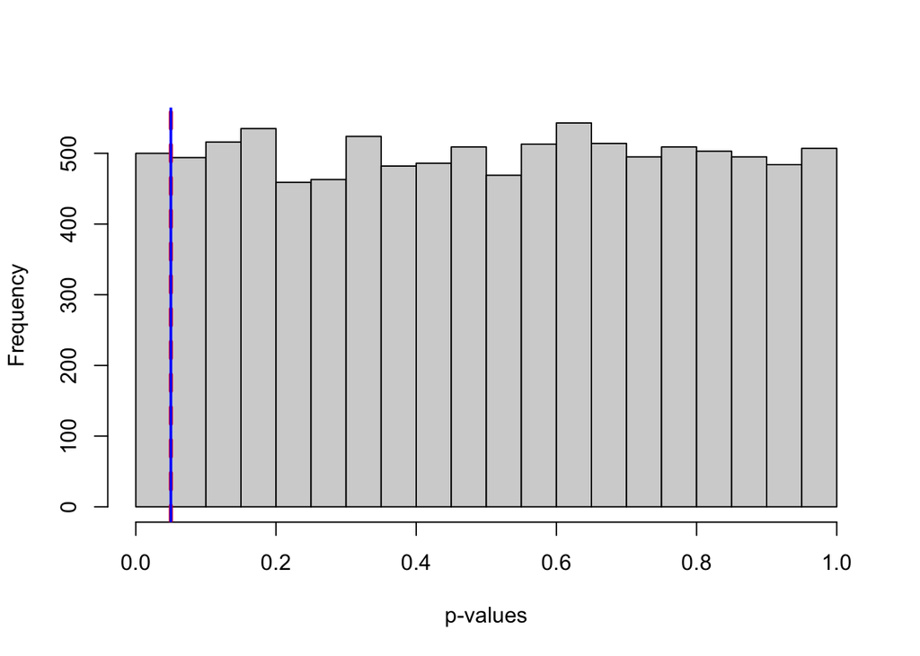

```r
## visualize distribution with simple plot
hist(p_vals, xlab = "p-values", main = "")
abline(v = .05, col = "red", lty = 2, lwd = 3) ## alpha value of .05
abline(v = prop_p, col = "blue", lwd = 2) ## computed false positive rate
```

The proportion of *p*-values < .05 (i.e., the proportion of significant results) that I see is: **0.05**.

> Next, do this using the `replicate` function:

```r
## run t.test simulation
p_sim_replicates <- replicate(n = n_sims,
                      expr = t.test(rnorm(n_per_run))$p.value,
                      simplify = TRUE)

## get proportion of p-values
prop_rep_p <- sum(p_sim_replicates < .05) / n_sims
prop_rep_p
```

```
## [1] 0.0523
```

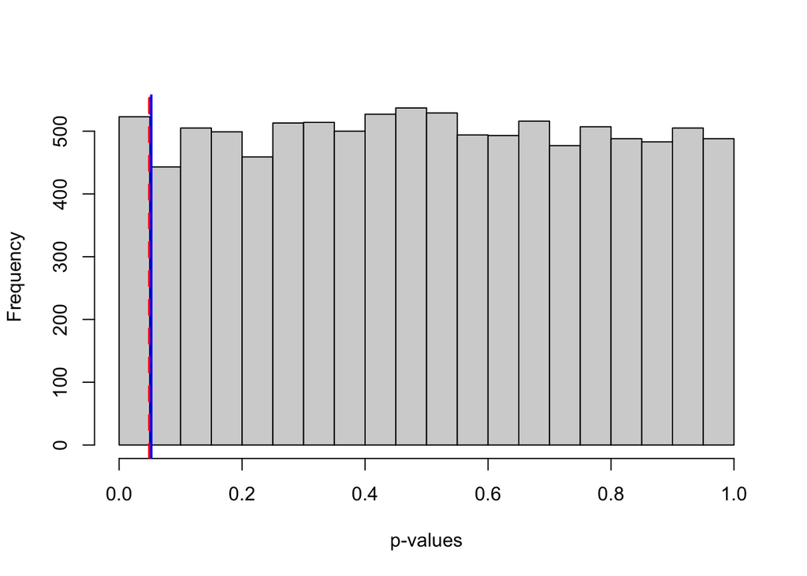

```r
## visualize distribution with simple plot
hist(p_sim_replicates, xlab = "p-values", main = "")
abline(v = .05, col = "red", lty = 2, lwd = 3) ## alpha value of .05
abline(v = prop_rep_p, col = "blue", lwd = 2) ## computed false positive rate
```

The proportion of *p*-values < .05 (i.e., the proportion of significant results) that I see is: **0.0523**.

> How does this compare to the intended false-positive rate of $\alpha=0.05$?

The results from this simulation compare favorably with the intended false-positive rate of $\alpha=0.05$, give or take the values being slightly above or below $\alpha=0.05$ due to randomness in sampling.

> Ok, that was a bit boring. Let’s try something more interesting - let’s implement a p-value sniffing simulation, in the style of Simons, Nelson, & Simonsohn (2011).

> Consider this scenario: you have done an experiment, again with 30 participants (one observation each, just for simplicity). The question is whether the true mean is different from 0. You aren’t going to check the p-value every trial, but let’s say you run 30 - then if the p-value is within the range p < .25 and p > .05, you optionally run 30 more and add those data, then test again. But if the original p value is < .05, you call it a day, and if the original is > .25, you also stop.

> First, write a function that implements this sampling regime.

```r
double.sample <- function(n_participants = 30, p_lower = .05, p_upper = .25) {
  ## get random draw of data from normal distribution
  sampled_data <- rnorm(n = n_participants)

  ## obtain p-value for two-sided test for difference from value of 0
  p_val <- t.test(sampled_data)$p.value

  ## compare p-value against lower/upper bound to determine if additional data
  ##  collection should occur
  if(p_val < p_upper & p_val > p_lower) {
    sampled_data <- c(sampled_data, rnorm(n = n_participants))
    p_val <- t.test(sampled_data)$p.value
  } else if(p_val > p_upper | p_val < p_lower) {
    ## if p-value is < .05 or > upper bound, then don't add additional data
    p_val <- p_val
  }

  return(p_val)
}
```

> Now call this function 10k times and find out what happens.

```r
n_sims <- 10000
ds_replicates <- replicate(n = n_sims,
                            expr = double.sample(),
                            simplify = TRUE)

## get proportion of p-values
prop_ds_reps_p <- sum(ds_replicates < .05) / n_sims
prop_ds_reps_p
```

```
## [1] 0.0717
```

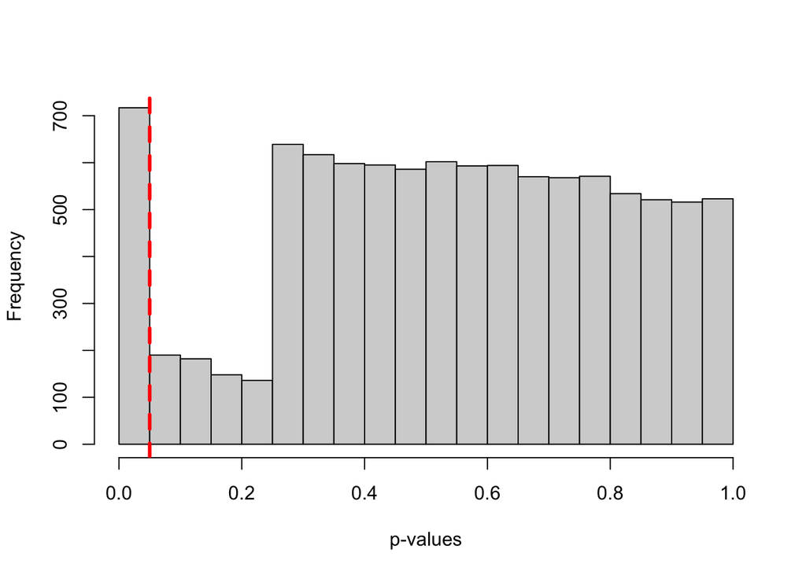

```r
## visualize distribution with simple plot
hist(ds_replicates, xlab = "p-values", main = "")
abline(v = .05, col = "red", lty = 2, lwd = 3) ## alpha value of .05
```

> Is there an inflation of false positives? How bad is it?

The proportion of *p*-values < .05 (i.e., the proportion of significant results) that I see is: **0.0717**. This value, give or take, is slightly inflated above the false-positive rate of $\alpha=0.05$.

> Now modify this code so that you can investigate this “double the sample” rule in a bit more depth. In the previous question, the researcher doubles the sample only when they think they got “close” to a significant result, i.e. when their not-significant p is less than 0.25. What if the researcher was more optimistic? See what happens in these 3 other scenarios:
> - The researcher doubles the sample whenever their p-value is not significant, but it’s less than 0.5.
> - The researcher doubles the sample whenever their p-value is not significant, but it’s less than 0.75.
> - The research doubles their sample whenever they get ANY pvalue that is not significant.

> HINT: Try to do this by making the function `double.sample` take the upper p value as an argument, so that you can pass this through dplyr.

> HINT 2: You may need more samples. Find out by looking at how the results change from run to run.

**The researcher doubles the sample whenever their p-value is not significant, but it’s less than 0.5.**

```r
n_sims <- 20000
ds_replicates_05 <- replicate(n = n_sims,
                            expr = double.sample(p_upper = 0.5),
                            simplify = TRUE)

## get proportion of p-values < .05
prop_ds_reps_05_p <- sum(ds_replicates_05 < .05) / n_sims
prop_ds_reps_05_p
```

```
## [1] 0.0783
```

**The researcher doubles the sample whenever their p-value is not significant, but it’s less than 0.75.**

```r
ds_replicates_75 <- replicate(n = n_sims,
                            expr = double.sample(p_upper = 0.75),
                            simplify = TRUE)

## get proportion of p-values < .05
prop_ds_reps_75_p <- sum(ds_replicates_75 < .05) / n_sims
prop_ds_reps_75_p
```

```
## [1] 0.0849
```

**The research doubles their sample whenever they get ANY pvalue that is not significant.**

```r
ds_replicates_all <- replicate(n = n_sims,
                            expr = double.sample(p_upper = 1),
                            simplify = TRUE)

## get proportion of p-values < .05
prop_ds_reps_all_p <- sum(ds_replicates_all < .05) / n_sims
prop_ds_reps_all_p
```

```
## [1] 0.08585
```

> How do these choices affect the false positive rate?

From visual inspection (see figure below), it appears that as the upper-limit *p*-value, that is used to decide whether or not data collection should continue with an additional 30 participants (i.e., doubling the sample) when the *p*-value is not significant, increases, so does the false-positive rate. In all cases, the false-positive rate is inflated above $\alpha=0.05$ for *n* = 20,000 replicates of each.

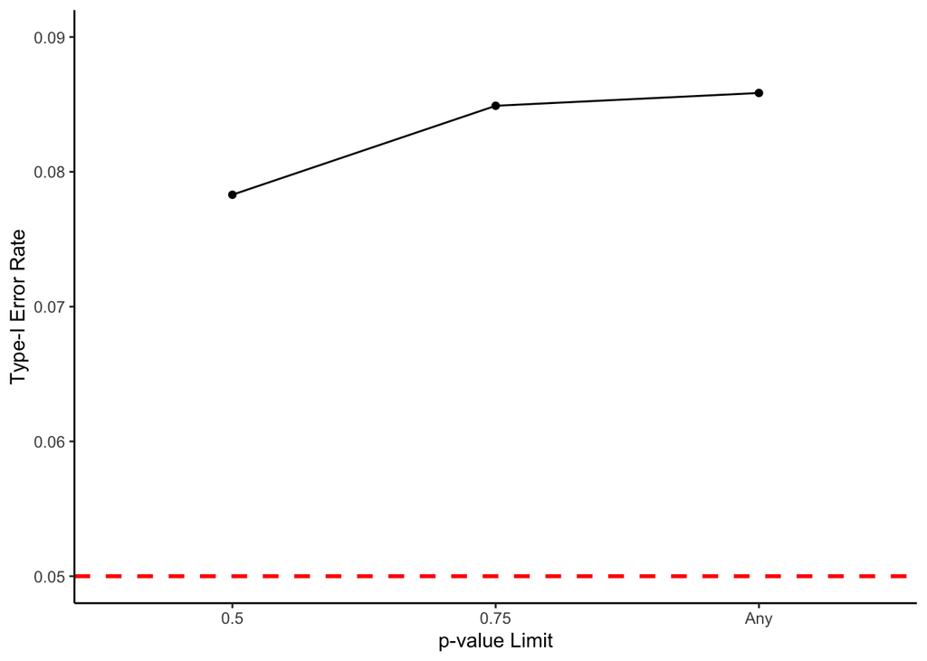

```r
p_limits <- c("0.5", "0.75", "Any")
false_positives <- c(prop_ds_reps_05_p, prop_ds_reps_75_p, prop_ds_reps_all_p)
fp_rates_df <- data.frame(p = p_limits,
                          fp_rate = false_positives)

ggplot(fp_rates_df, aes(x = p, y = fp_rate)) +
  geom_point() +
  geom_line(group = 1) +
  ylim(c(0.05, .09)) +
  geom_hline(yintercept = .05, linetype="dashed", color = "red", size = 1) +
  xlab("p-value Limit") +
  ylab("Type-I Error Rate") +
  theme_classic()
```

> What do you conclude on the basis of this simulation? How bad is this kind of data-dependent policy?

Overall, the data indicate that as the upper-bound *p*-value limit of the current data increases towards 1, the false-positive rate increases as well. Thus, what is bad about this kind of data-dependent policy is that if after 30 participants worth of data have been collected and there is largely no effect (i.e., up to *p*-value > .99), the activity of doubling your sample only makes the likelihood of having a false positive effect occur even higher.